# midterm

21400022 YounhongKo

2020 4 24

## Import Library & Read CSV File

```r
load("midterm2020.RData")
library(tidyr)
library(stringr)
```

# Part 1 - Data Exploratation and Preparation

## Problem 1

```r
str(pums.sample)
```

```
## 'data.frame':    2672 obs. of  10 variables:
##  $ PINCP: num  22900 17800 56800 6100 12000 26300 7100 16200 31500 14000 ...
##  $ SEX  : num  1 2 1 2 2 2 2 2 1 1 ...
##  $ AGEP : num  43 51 55 23 23 73 49 42 56 42 ...
##  $ MAR  : num  1 1 1 5 5 2 2 5 1 1 ...
##  $ COW  : Factor w/ 7 levels "Employee of a private for-profit",..: 1 3 1 1 1 1 1 1 1 1 ...
##  $ SCHL : Factor w/ 9 levels "no high school diploma",..: 4 2 4 3 4 4 1 2 2 1 ...
##  $ WKHP : num  40 35 50 23 40 40 20 40 40 50 ...
##  $ FER  : Factor w/ 2 levels "no","yes": NA NA NA 2 1 NA 1 1 NA NA ...
##  $ JWMNP: num  5 40 15 28 10 30 50 10 10 60 ...
##  $ DIS  : Factor w/ 2 levels "w/disability",..: 2 2 1 2 2 1 1 2 2 2 ...
```

## Problem 2

```r
pums.sample$SEX <- as.character(pums.sample$SEX)
pums.sample$SEX <- ifelse(pums.sample$SEX=="1", "Male", "Female")
pums.sample$SEX <- as.factor(pums.sample$SEX)
```

## Problem 3

```r
pums.sample$MAR <- as.character(pums.sample$MAR)
pums.sample$MAR <-
    ifelse(pums.sample$MAR == "1", "Married",
    ifelse(pums.sample$MAR == "2", "Widowed",
    ifelse(pums.sample$MAR == "3", "Divorced",
    ifelse(pums.sample$MAR == "4", "Separated",
           "Never married or under 15 years old"))))
pums.sample$MAR <- as.factor(pums.sample$MAR)
str(pums.sample$MAR)
```

```
##  Factor w/ 5 levels "Divorced","Married",..: 2 2 2 3 3 5 5 3 2 2 ...
```

## Problem 4

```r
colSums(is.na(pums.sample))
```

```
## PINCP   SEX  AGEP   MAR   COW  SCHL  WKHP   FER JWMNP   DIS
##     0     0     0     0     6     0     0  1798   119     0
```

```r
colSums(is.na(pums.sample)) / 2672 * 100
```

```
##      PINCP        SEX       AGEP        MAR        COW       SCHL       WKHP
##  0.0000000  0.0000000  0.0000000  0.0000000  0.2245509  0.0000000  0.0000000
##        FER      JWMNP        DIS
## 67.2904192  4.4535928  0.0000000
```

> FER, JWMNP has missing values of 1798, 119 each. It’s percentage is about 67.2%, 4.4% each.

## Problem 5

```r
total <- sum(is.na(pums.sample$FER))
total
```

```
## [1] 1798
```

```r
total_male <- sum(pums.sample$SEX=="Male")
male_fer <- sum(is.na(pums.sample$FER) & pums.sample$SEX=="Male")
total_male - male_fer
```

```
## [1] 0
```

```r
female_under15 <- sum(pums.sample$SEX=="Female" & pums.sample$AGEP<15)
female_fer_under15 <- sum(is.na(pums.sample$FER) & pums.sample$SEX=="Female" & pums.sample$AGEP < 15)
female_under15 - female_fer_under15
```

```
## [1] 0
```

```r
female_over50 <- sum(pums.sample$SEX=="Female" & pums.sample$AGEP>50)
female_fer_over50 <- sum(is.na(pums.sample$FER) & pums.sample$SEX=="Female" & pums.sample$AGEP > 50)
female_over50 - female_fer_over50
```

```
## [1] 0
```

```r
total - male_fer - female_fer_over50 - female_fer_under15
```

```
## [1] 0
```

> 1. For all male, FER is missing
> 2. For all female age under 15, FER is missing
> 3. For all female age over 50, FER is missing
> 4. There are no other missing FER values.

## Problem 6

```r
summary(pums.sample)
```

```
##      PINCP            SEX            AGEP
##  Min.   : -8700   Female:1279   Min.   :16.00
##  1st Qu.: 16000   Male  :1393   1st Qu.:31.00
##  Median : 32000                 Median :43.00
##  Mean   : 45651                 Mean   :42.65
##  3rd Qu.: 56130                 3rd Qu.:53.00
##  Max.   :570000                 Max.   :84.00
##
##                                   MAR
##  Divorced                           : 316
##  Married                            :1492
##  Never married or under 15 years old: 747
##  Separated                          :  53
##  Widowed                            :  64
##
##
##                                COW                                   SCHL
##  Employee of a private for-profit:1716   some college credit, no degree:662
##  Private not-for-profit employee : 267   Regular high school diploma   :645
##  Local government employee       : 195   Bachelor's degree             :486
##  Self-employed not incorporated  : 187   no high school diploma        :272
##  State government employee       : 126   Associate's degree            :216
##  (Other)                         : 175   Master's degree               :209
##  NA's                            :   6   (Other)                       :182
##       WKHP         FER           JWMNP                  DIS
##  Min.   : 1.00   no  : 836   Min.   :  1.0   w/disability : 178
##  1st Qu.:35.00   yes :  38   1st Qu.: 10.0   no disability:2494
##  Median :40.00   NA's:1798   Median : 20.0
##  Mean   :38.21               Mean   : 25.6
##  3rd Qu.:40.00               3rd Qu.: 30.0
##  Max.   :99.00               Max.   :162.0
##                              NA's   :119
```

```r
pums.sample[pums.sample$PINCP <= 0, ]
```

```
##      PINCP  SEX AGEP     MAR                            COW
## 431  -8700 Male   40 Married Self-employed not incorporated
## 1321 -8000 Male   50 Married Self-employed not incorporated
##                        SCHL WKHP  FER JWMNP           DIS
## 431       Bachelor's degree   40 <NA>    20 no disability
## 1321 no high school diploma   80 <NA>     2 no disability
```

```r
pums.sample[pums.sample$PINCP > 500000, ]
```

```
##       PINCP    SEX AGEP                                 MAR
## 1097 570000   Male   65                             Married
## 1592 507000   Male   35                             Married
## 1608 532000   Male   34 Never married or under 15 years old
## 1621 507000   Male   49                             Married
## 1637 507000 Female   51                            Divorced
## 1688 507000   Male   47                             Married
##                                   COW                SCHL WKHP  FER JWMNP
## 1097 Employee of a private for-profit   Bachelor's degree   32 <NA>    15
## 1592 Employee of a private for-profit   Bachelor's degree   45 <NA>    75
## 1608 Employee of a private for-profit   Bachelor's degree   65 <NA>    15
## 1621 Employee of a private for-profit Professional degree   50 <NA>    30
## 1637 Employee of a private for-profit   Bachelor's degree   55 <NA>    30
## 1688 Employee of a private for-profit   Bachelor's degree   60 <NA>    65
##                DIS
## 1097  w/disability
## 1592 no disability
## 1608 no disability
## 1621 no disability
## 1637 no disability
## 1688 no disability
```

```r
head(pums.sample[pums.sample$WKHP < 7, ])
```

```
##     PINCP    SEX AGEP                                 MAR
## 17  22160 Female   64                             Married
## 39  32900 Female   77                            Divorced
## 70  59270   Male   64                             Married
## 72   3400   Male   60                             Married
## 119 29300 Female   82                             Widowed
## 153 16800   Male   30 Never married or under 15 years old
##                                  COW                           SCHL WKHP  FER
## 17    Self-employed not incorporated  GED or alternative credential    2 <NA>
## 39  Employee of a private for-profit some college credit, no degree    5 <NA>
## 70   Private not-for-profit employee                Master's degree    6 <NA>
## 72        Self-employed incorporated                Master's degree    4 <NA>
## 119  Private not-for-profit employee         no high school diploma    3 <NA>
## 153 Employee of a private for-profit some college credit, no degree    1 <NA>
##     JWMNP           DIS
## 17     30 no disability
## 39     30 no disability
## 70     40 no disability
## 72     20 no disability
## 119    10 no disability
## 153    20 no disability
```

```r
head(pums.sample[pums.sample$WKHP >= 90, ])
```

```
##       PINCP  SEX AGEP                                 MAR
## 271  120000 Male   36 Never married or under 15 years old
## 713  150000 Male   60                             Married
## 1176  39300 Male   29 Never married or under 15 years old
## 1431  30000 Male   61                             Married
## 1827  40000 Male   54                             Married
## 1975 323000 Male   55                             Married
##                                   COW                        SCHL WKHP  FER
## 271  Employee of a private for-profit      no high school diploma   90 <NA>
## 713  Employee of a private for-profit           Bachelor's degree   99 <NA>
## 1176   Self-employed not incorporated           Bachelor's degree   99 <NA>
## 1431   Self-employed not incorporated Regular high school diploma   90 <NA>
## 1827 Employee of a private for-profit Regular high school diploma   99 <NA>
## 1975       Self-employed incorporated         Professional degree   95 <NA>
##      JWMNP           DIS
## 271     20 no disability
## 713     25 no disability
## 1176     2 no disability
## 1431     1 no disability
## 1827     2 no disability
## 1975    15 no disability
```

> 1. PINCP has a multiple outliers.
> 2. PINCP has negative min value. But it needs to be checked since it can be minus income(dept).
> 3. PINCP has max value which is about 10 times higher than 3rd quarter value. It can be true depending on where they are working.
> 4. WKHP has very low min value which is 1. Since their income is not high, it can be true but needs to be checked.
> 5. WKHP has very high max value which is 99. It needs to be checked whether it is exceeding working hours that government has chosen.
> 6. Those are not obvious errors since it is a possible value.

## Problem 7

```r
table(pums.sample$COW, pums.sample$SCHL)
```

```
##
##                                    no high school diploma
##   Employee of a private for-profit                    210
##   Private not-for-profit employee                      15
##   Local government employee                            15
##   State government employee                             3
##   Federal government employee                           2
##   Self-employed not incorporated                       24
##   Self-employed incorporated                            3
##
##                                    Regular high school diploma
##   Employee of a private for-profit                         459
##   Private not-for-profit employee                           49
##   Local government employee                                 39
##   State government employee                                 15
##   Federal government employee                               11
##   Self-employed not incorporated                            43
##   Self-employed incorporated                                28
##
##                                    GED or alternative credential
##   Employee of a private for-profit                            55
##   Private not-for-profit employee                              8
##   Local government employee                                    6
##   State government employee                                    8
##   Federal government employee                                  3
##   Self-employed not incorporated                              10
##   Self-employed incorporated                                   3
##
##                                    some college credit, no degree
##   Employee of a private for-profit                            451
##   Private not-for-profit employee                              62
##   Local government employee                                    38
##   State government employee                                    28
##   Federal government employee                                  14
##   Self-employed not incorporated                               48
##   Self-employed incorporated                                   18
##
##                                    Associate's degree Bachelor's degree
##   Employee of a private for-profit                134               283
##   Private not-for-profit employee                  26                56
```

[output cut: 8 more lines]

```
##   Private not-for-profit employee               34                  10
##   Local government employee                     32                   7
##   State government employee                     21                   0
##   Federal government employee                   11                   4
##   Self-employed not incorporated                13                   6
##   Self-employed incorporated                    10                   7
##
##                                    Doctorate degree
##   Employee of a private for-profit               12
##   Private not-for-profit employee                 7
##   Local government employee                       2
##   State government employee                       7
##   Federal government employee                     0
##   Self-employed not incorporated                  3
##   Self-employed incorporated                      0
```

```r
prop.table(table(pums.sample$COW, pums.sample$SCHL), margin = 2) * 100
```

```
##
##                                    no high school diploma
##   Employee of a private for-profit             77.2058824
##   Private not-for-profit employee               5.5147059
##   Local government employee                     5.5147059
##   State government employee                     1.1029412
##   Federal government employee                   0.7352941
##   Self-employed not incorporated                8.8235294
##   Self-employed incorporated                    1.1029412
##
##                                    Regular high school diploma
##   Employee of a private for-profit                  71.2732919
##   Private not-for-profit employee                    7.6086957
##   Local government employee                          6.0559006
##   State government employee                          2.3291925
##   Federal government employee                        1.7080745
##   Self-employed not incorporated                     6.6770186
##   Self-employed incorporated                         4.3478261
##
##                                    GED or alternative credential
##   Employee of a private for-profit                    59.1397849
##   Private not-for-profit employee                      8.6021505
##   Local government employee                            6.4516129
##   State government employee                            8.6021505
##   Federal government employee                          3.2258065
##   Self-employed not incorporated                      10.7526882
##   Self-employed incorporated                           3.2258065
##
##                                    some college credit, no degree
##   Employee of a private for-profit                     68.4370258
##   Private not-for-profit employee                       9.4081942
##   Local government employee                             5.7663126
##   State government employee                             4.2488619
##   Federal government employee                           2.1244310
##   Self-employed not incorporated                        7.2837633
##   Self-employed incorporated                            2.7314112
##
##                                    Associate's degree Bachelor's degree
##   Employee of a private for-profit         62.0370370        58.4710744
##   Private not-for-profit employee          12.0370370        11.5702479
```

[output cut: 8 more lines]

```
##   Private not-for-profit employee       16.2679426          17.2413793
##   Local government employee             15.3110048          12.0689655
##   State government employee             10.0478469           0.0000000
##   Federal government employee            5.2631579           6.8965517
##   Self-employed not incorporated         6.2200957          10.3448276
##   Self-employed incorporated             4.7846890          12.0689655
##
##                                    Doctorate degree
##   Employee of a private for-profit       38.7096774
##   Private not-for-profit employee        22.5806452
##   Local government employee               6.4516129
##   State government employee              22.5806452
##   Federal government employee             0.0000000
##   Self-employed not incorporated          9.6774194
##   Self-employed incorporated              0.0000000
```

> With no high school disploma, most of them are having lowest level of work. As education level increases, percentage of lowest level of work decreases, and higher level of working percentage goes up.

## Problem 8

```r
pums.sample$age_income <-
    cut(pums.sample$AGEP, breaks = c(0, 29, 39, 49, 59, 85),
        labels = c("Under 30", "Under 40", "Under 50", "Under 60", "Over 60"),
        include.lowest = T)

aggregate(PINCP~age_income, pums.sample, mean)
```

```
##   age_income    PINCP
## 1   Under 30 21306.69
## 2   Under 40 48491.21
## 3   Under 50 51634.66
## 4   Under 60 55747.96
## 5    Over 60 55829.38
```

> Age over 60 has highest average income, while age under 30 has lowest average income.

## Problem 9

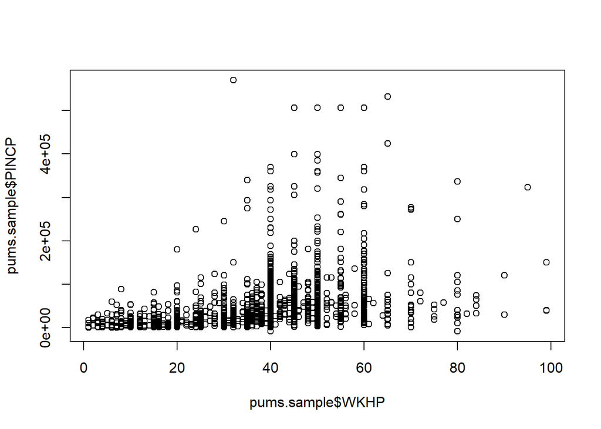

```r
plot(x=pums.sample$WKHP, y=pums.sample$PINCP)
```

> 1. People with high income work about 30~60 hours per week.

> 2. You can also find out that most of PINCP is populated on the bottom of graph.

## Problem 10

```r
save(pums.sample, file = "st21400022.RData")
```

> Save pums.sample data to RData file.

# Part 2 - Data Transformation

## Problem 1 && Problem 2

```r
iris$id <-1:nrow(iris)
iris.tidy <- gather(iris, PartMeasure, Value, Sepal.Length:Petal.Width)
iris.tidy <- separate(iris.tidy, PartMeasure, into=c("Part", "Measure"))
iris.wide <- spread(iris.tidy, Measure, Value)
```

```r
head(iris.wide, 12)
```

```
##    Species  Part Length Width
## 1   setosa Petal    1.4   0.2
## 2   setosa Sepal    5.1   3.5
## 3   setosa Petal    1.4   0.2
## 4   setosa Sepal    4.9   3.0
## 5   setosa Petal    1.3   0.2
## 6   setosa Sepal    4.7   3.2
## 7   setosa Petal    1.5   0.2
## 8   setosa Sepal    4.6   3.1
## 9   setosa Petal    1.4   0.2
## 10  setosa Sepal    5.0   3.6
## 11  setosa Petal    1.7   0.4
## 12  setosa Sepal    5.4   3.9
```

```r
str(iris.wide)
```

[output not shown]

```r
head(iris.tidy, 15)
```

```
##    Species  Part Measure Value
## 1   setosa Sepal  Length   5.1
## 2   setosa Sepal  Length   4.9
## 3   setosa Sepal  Length   4.7
## 4   setosa Sepal  Length   4.6
## 5   setosa Sepal  Length   5.0
## 6   setosa Sepal  Length   5.4
## 7   setosa Sepal  Length   4.6
## 8   setosa Sepal  Length   5.0
## 9   setosa Sepal  Length   4.4
## 10  setosa Sepal  Length   4.9
## 11  setosa Sepal  Length   5.4
## 12  setosa Sepal  Length   4.8
## 13  setosa Sepal  Length   4.8
## 14  setosa Sepal  Length   4.3
## 15  setosa Sepal  Length   5.8
```

```r
str(iris.tidy)
```

[output not shown]

> 1. iris.wide now has 300 observations with 4 variables with Species, Part, Length, and Width.
> 2. iris.tidy now has 600 observations with 4 variables with Species, Part, Measure, and Value.

```r
save(pums.sample, iris.tidy, iris.wide, file = "st21400022.RData")
```

> Save iris.wide and iris.tidy to RData file with pums.sample from Part1